# Automobile

## 1. Import and warehouse data:

```python
import numpy as np
from sklearn.linear_model import LinearRegression
from scipy import stats
from scipy.stats import zscore
from scipy.cluster.hierarchy import dendrogram, linkage
from scipy.cluster.hierarchy import fcluster
from sklearn.cluster import KMeans
from sklearn.metrics import silhouette_samples, silhouette_score
import pandas as pd
import matplotlib.pyplot as plt
import seaborn as sns
%matplotlib inline
sns.set(color_codes=True)
%matplotlib inline
import warnings
warnings.filterwarnings('ignore')
from sklearn.model_selection import train_test_split
```

```python
df1 = pd.read_json('Part1 - Car-Attributes.json')
```

```python
df1.to_csv('Part1 - Car-Attributes.csv',index=False)
```

```python
df1
```

|  | mpg | cyl | disp | hp | wt | acc | yr | origin |
| --- | --- | --- | --- | --- | --- | --- | --- | --- |
| 0 | 18.0 | 8 | 307.0 | 130 | 3504 | 12.0 | 70 | 1 |
| 1 | 15.0 | 8 | 350.0 | 165 | 3693 | 11.5 | 70 | 1 |
| 2 | 18.0 | 8 | 318.0 | 150 | 3436 | 11.0 | 70 | 1 |
| 3 | 16.0 | 8 | 304.0 | 150 | 3433 | 12.0 | 70 | 1 |
| 4 | 17.0 | 8 | 302.0 | 140 | 3449 | 10.5 | 70 | 1 |
| ... | ... | ... | ... | ... | ... | ... | ... | ... |
| 393 | 27.0 | 4 | 140.0 | 86 | 2790 | 15.6 | 82 | 1 |
| 394 | 44.0 | 4 | 97.0 | 52 | 2130 | 24.6 | 82 | 2 |
| 395 | 32.0 | 4 | 135.0 | 84 | 2295 | 11.6 | 82 | 1 |
| 396 | 28.0 | 4 | 120.0 | 79 | 2625 | 18.6 | 82 | 1 |
| 397 | 31.0 | 4 | 119.0 | 82 | 2720 | 19.4 | 82 | 1 |

398 rows × 8 columns

```python
df1.shape
```

```
(398, 8)
```

```python
df1.head()
```

|  | mpg | cyl | disp | hp | wt | acc | yr | origin |
| --- | --- | --- | --- | --- | --- | --- | --- | --- |
| 0 | 18.0 | 8 | 307.0 | 130 | 3504 | 12.0 | 70 | 1 |
| 1 | 15.0 | 8 | 350.0 | 165 | 3693 | 11.5 | 70 | 1 |
| 2 | 18.0 | 8 | 318.0 | 150 | 3436 | 11.0 | 70 | 1 |
| 3 | 16.0 | 8 | 304.0 | 150 | 3433 | 12.0 | 70 | 1 |
| 4 | 17.0 | 8 | 302.0 | 140 | 3449 | 10.5 | 70 | 1 |

```python
df1.info()
```

```
<class 'pandas.core.frame.DataFrame'>
RangeIndex: 398 entries, 0 to 397
Data columns (total 8 columns):
 #   Column  Non-Null Count  Dtype
---  ------  --------------  -----
 0   mpg     398 non-null    float64
 1   cyl     398 non-null    int64
 2   disp    398 non-null    float64
 3   hp      398 non-null    object
 4   wt      398 non-null    int64
 5   acc     398 non-null    float64
 6   yr      398 non-null    int64
 7   origin  398 non-null    int64
dtypes: float64(3), int64(4), object(1)
memory usage: 25.0+ KB
```

```python
df1.size
```

```
3184
```

```python
df2 = pd.read_csv('Part1 - Car name.csv')
```

```python
df2
```

|  | car_name |
| --- | --- |
| 0 | chevrolet chevelle malibu |
| 1 | buick skylark 320 |
| 2 | plymouth satellite |
| 3 | amc rebel sst |
| 4 | ford torino |
| ... | ... |
| 393 | ford mustang gl |
| 394 | vw pickup |
| 395 | dodge rampage |
| 396 | ford ranger |
| 397 | chevy s-10 |

398 rows × 1 columns

```python
df2.shape
```

```
(398, 1)
```

```python
df2.head()
```

|  | car_name |
| --- | --- |
| 0 | chevrolet chevelle malibu |
| 1 | buick skylark 320 |
| 2 | plymouth satellite |
| 3 | amc rebel sst |
| 4 | ford torino |

```python
df2.size
```

```
398
```

```python
df = pd.concat([df1,df2],axis=1)
```

```python
df
```

|  | mpg | cyl | disp | hp | wt | acc | yr | origin | car_name |
| --- | --- | --- | --- | --- | --- | --- | --- | --- | --- |
| 0 | 18.0 | 8 | 307.0 | 130 | 3504 | 12.0 | 70 | 1 | chevrolet chevelle malibu |
| 1 | 15.0 | 8 | 350.0 | 165 | 3693 | 11.5 | 70 | 1 | buick skylark 320 |
| 2 | 18.0 | 8 | 318.0 | 150 | 3436 | 11.0 | 70 | 1 | plymouth satellite |
| 3 | 16.0 | 8 | 304.0 | 150 | 3433 | 12.0 | 70 | 1 | amc rebel sst |
| 4 | 17.0 | 8 | 302.0 | 140 | 3449 | 10.5 | 70 | 1 | ford torino |
| ... | ... | ... | ... | ... | ... | ... | ... | ... | ... |
| 393 | 27.0 | 4 | 140.0 | 86 | 2790 | 15.6 | 82 | 1 | ford mustang gl |
| 394 | 44.0 | 4 | 97.0 | 52 | 2130 | 24.6 | 82 | 2 | vw pickup |
| 395 | 32.0 | 4 | 135.0 | 84 | 2295 | 11.6 | 82 | 1 | dodge rampage |
| 396 | 28.0 | 4 | 120.0 | 79 | 2625 | 18.6 | 82 | 1 | ford ranger |
| 397 | 31.0 | 4 | 119.0 | 82 | 2720 | 19.4 | 82 | 1 | chevy s-10 |

398 rows × 9 columns

```python
df.head()
```

|  | mpg | cyl | disp | hp | wt | acc | yr | origin | car_name |
| --- | --- | --- | --- | --- | --- | --- | --- | --- | --- |
| 0 | 18.0 | 8 | 307.0 | 130 | 3504 | 12.0 | 70 | 1 | chevrolet chevelle malibu |
| 1 | 15.0 | 8 | 350.0 | 165 | 3693 | 11.5 | 70 | 1 | buick skylark 320 |
| 2 | 18.0 | 8 | 318.0 | 150 | 3436 | 11.0 | 70 | 1 | plymouth satellite |
| 3 | 16.0 | 8 | 304.0 | 150 | 3433 | 12.0 | 70 | 1 | amc rebel sst |
| 4 | 17.0 | 8 | 302.0 | 140 | 3449 | 10.5 | 70 | 1 | ford torino |

```python
df.shape
```

```
(398, 9)
```

```python
df.size
```

```
3582
```

```python
df.to_csv('Automobile.csv', index=False)
```

```python
datatoexcel = pd.ExcelWriter('Automobile.xlsx')
```

```python
df.to_excel(datatoexcel)
```

```python
df.to_json('Automobile.json', orient = 'split', compression = 'infer', index = 'true')
```

## 2. Data cleansing:

```python
df = df.drop('car_name', axis=1)
```

```python
df['origin'] = df['origin'].replace({1: 'INDIA', 2: 'DUBAI', 3: 'TORONTO'})
df.head()
```

|  | mpg | cyl | disp | hp | wt | acc | yr | origin |
| --- | --- | --- | --- | --- | --- | --- | --- | --- |
| 0 | 18.0 | 8 | 307.0 | 130 | 3504 | 12.0 | 70 | INDIA |
| 1 | 15.0 | 8 | 350.0 | 165 | 3693 | 11.5 | 70 | INDIA |
| 2 | 18.0 | 8 | 318.0 | 150 | 3436 | 11.0 | 70 | INDIA |
| 3 | 16.0 | 8 | 304.0 | 150 | 3433 | 12.0 | 70 | INDIA |
| 4 | 17.0 | 8 | 302.0 | 140 | 3449 | 10.5 | 70 | INDIA |

```python
df.info()
```

```
<class 'pandas.core.frame.DataFrame'>
RangeIndex: 398 entries, 0 to 397
Data columns (total 8 columns):
 #   Column  Non-Null Count  Dtype
---  ------  --------------  -----
 0   mpg     398 non-null    float64
 1   cyl     398 non-null    int64
 2   disp    398 non-null    float64
 3   hp      398 non-null    object
 4   wt      398 non-null    int64
 5   acc     398 non-null    float64
 6   yr      398 non-null    int64
 7   origin  398 non-null    object
dtypes: float64(3), int64(3), object(2)
memory usage: 25.0+ KB
```

```python
df.describe().T
```

|  | count | mean | std | min | 25% | 50% | 75% | max |
| --- | --- | --- | --- | --- | --- | --- | --- | --- |
| mpg | 398.0 | 23.514573 | 7.815984 | 9.0 | 17.500 | 23.0 | 29.000 | 46.6 |
| cyl | 398.0 | 5.454774 | 1.701004 | 3.0 | 4.000 | 4.0 | 8.000 | 8.0 |
| disp | 398.0 | 193.425879 | 104.269838 | 68.0 | 104.250 | 148.5 | 262.000 | 455.0 |
| wt | 398.0 | 2970.424623 | 846.841774 | 1613.0 | 2223.750 | 2803.5 | 3608.000 | 5140.0 |
| acc | 398.0 | 15.568090 | 2.757689 | 8.0 | 13.825 | 15.5 | 17.175 | 24.8 |
| yr | 398.0 | 76.010050 | 3.697627 | 70.0 | 73.000 | 76.0 | 79.000 | 82.0 |

```python
hpIsDigit = pd.DataFrame(df.hp.str.isdigit())
```

```python
df[hpIsDigit['hp'] == False]
```

|  | mpg | cyl | disp | hp | wt | acc | yr | origin |
| --- | --- | --- | --- | --- | --- | --- | --- | --- |
| 32 | 25.0 | 4 | 98.0 | ? | 2046 | 19.0 | 71 | INDIA |
| 126 | 21.0 | 6 | 200.0 | ? | 2875 | 17.0 | 74 | INDIA |
| 330 | 40.9 | 4 | 85.0 | ? | 1835 | 17.3 | 80 | DUBAI |
| 336 | 23.6 | 4 | 140.0 | ? | 2905 | 14.3 | 80 | INDIA |
| 354 | 34.5 | 4 | 100.0 | ? | 2320 | 15.8 | 81 | DUBAI |
| 374 | 23.0 | 4 | 151.0 | ? | 3035 | 20.5 | 82 | INDIA |

```python
df = df.replace('?', np.nan)
df[hpIsDigit['hp'] == False]
```

|  | mpg | cyl | disp | hp | wt | acc | yr | origin |
| --- | --- | --- | --- | --- | --- | --- | --- | --- |
| 32 | 25.0 | 4 | 98.0 | NaN | 2046 | 19.0 | 71 | INDIA |
| 126 | 21.0 | 6 | 200.0 | NaN | 2875 | 17.0 | 74 | INDIA |
| 330 | 40.9 | 4 | 85.0 | NaN | 1835 | 17.3 | 80 | DUBAI |
| 336 | 23.6 | 4 | 140.0 | NaN | 2905 | 14.3 | 80 | INDIA |
| 354 | 34.5 | 4 | 100.0 | NaN | 2320 | 15.8 | 81 | DUBAI |
| 374 | 23.0 | 4 | 151.0 | NaN | 3035 | 20.5 | 82 | INDIA |

```python
df.median()
```

```
mpg       23.0
cyl        4.0
disp     148.5
hp        93.5
wt      2803.5
acc       15.5
yr        76.0
dtype: float64
```

```python
df['hp'].fillna((df['hp'].median()), inplace=True)
```

```python
df.isnull().sum()
```

```
mpg       0
cyl       0
disp      0
hp        0
wt        0
acc       0
yr        0
origin    0
dtype: int64
```

```python
df['mpg_level'] = df['mpg'].apply(lambda x: 'low' if x<17 else 'high' if x>29 else 'medium')
df.head()
```

|  | mpg | cyl | disp | hp | wt | acc | yr | origin | mpg_level |
| --- | --- | --- | --- | --- | --- | --- | --- | --- | --- |
| 0 | 18.0 | 8 | 307.0 | 130.0 | 3504 | 12.0 | 70 | INDIA | medium |
| 1 | 15.0 | 8 | 350.0 | 165.0 | 3693 | 11.5 | 70 | INDIA | low |
| 2 | 18.0 | 8 | 318.0 | 150.0 | 3436 | 11.0 | 70 | INDIA | medium |
| 3 | 16.0 | 8 | 304.0 | 150.0 | 3433 | 12.0 | 70 | INDIA | low |
| 4 | 17.0 | 8 | 302.0 | 140.0 | 3449 | 10.5 | 70 | INDIA | medium |

```python
df_cat = df.iloc[:,[1,6,7,8]]
df_cat.head()
```

|  | cyl | yr | origin | mpg_level |
| --- | --- | --- | --- | --- |
| 0 | 8 | 70 | INDIA | medium |
| 1 | 8 | 70 | INDIA | low |
| 2 | 8 | 70 | INDIA | medium |
| 3 | 8 | 70 | INDIA | low |
| 4 | 8 | 70 | INDIA | medium |

```python
df_num = df.drop(['cyl','yr','origin','mpg_level'],axis=1)
df_num.head()
```

|  | mpg | disp | hp | wt | acc |
| --- | --- | --- | --- | --- | --- |
| 0 | 18.0 | 307.0 | 130.0 | 3504 | 12.0 |
| 1 | 15.0 | 350.0 | 165.0 | 3693 | 11.5 |
| 2 | 18.0 | 318.0 | 150.0 | 3436 | 11.0 |
| 3 | 16.0 | 304.0 | 150.0 | 3433 | 12.0 |
| 4 | 17.0 | 302.0 | 140.0 | 3449 | 10.5 |

## 3. Data analysis & visualisation:

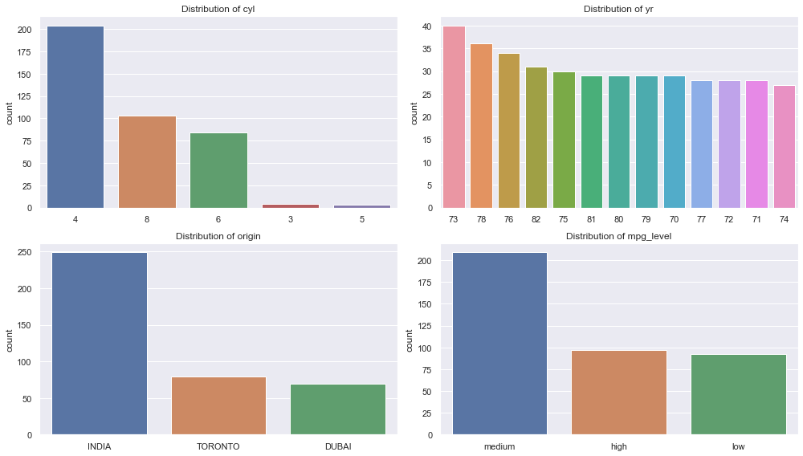

```python
fig = plt.figure(1, (14, 8))

for i,df in enumerate(df_cat.columns):
    ax = plt.subplot(2,2,i+1)
    sns.countplot(df_cat[df], order = df_cat[df].value_counts().index)
    ax.set_xlabel(None)
    ax.set_title(f'Distribution of {df}')
    plt.tight_layout()

plt.show()
```

INDIA 4 cylinder cars produced in 1973 with medium mpg level seem to dominate the dateset

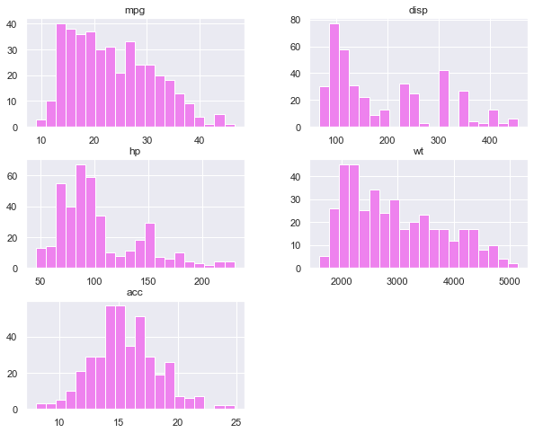

```python
df_num.hist(bins = 20, figsize = (10, 8), color = 'violet')
plt.show()
```

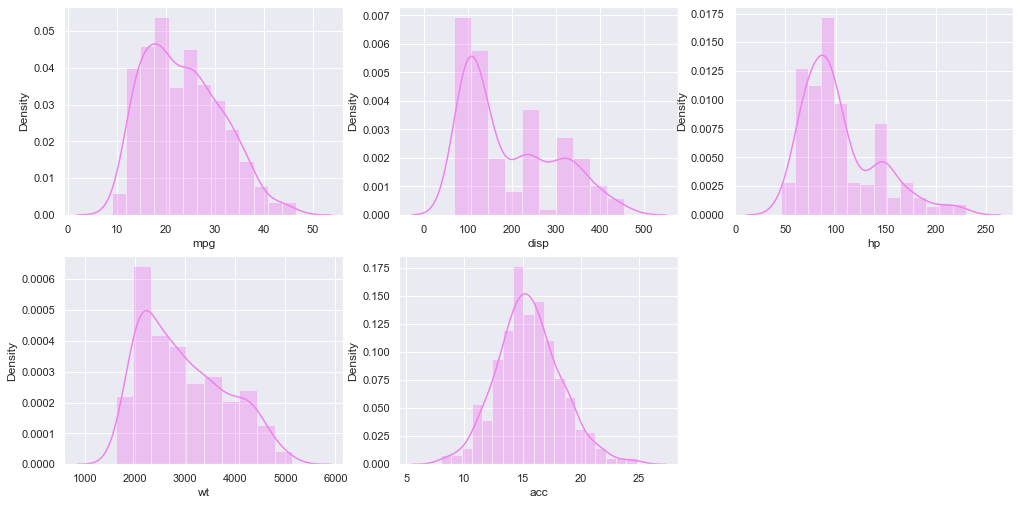

```python
plt.figure(figsize=(17, 13))
col = 1
for i in df_num.columns:
    plt.subplot(3, 3, col)
    sns.distplot(df_num[i], color = 'violet')
    col += 1
```

Displacement and Horsepower seem to be skewed to the right

```python
df = pd.concat([df_cat,df_num],axis=1)
```

```python
df.info()
```

```
<class 'pandas.core.frame.DataFrame'>
RangeIndex: 398 entries, 0 to 397
Data columns (total 9 columns):
 #   Column     Non-Null Count  Dtype
---  ------     --------------  -----
 0   cyl        398 non-null    int64
 1   yr         398 non-null    int64
 2   origin     398 non-null    object
 3   mpg_level  398 non-null    object
 4   mpg        398 non-null    float64
 5   disp       398 non-null    float64
 6   hp         398 non-null    float64
 7   wt         398 non-null    int64
 8   acc        398 non-null    float64
dtypes: float64(4), int64(3), object(2)
memory usage: 28.1+ KB
```

```python
df = pd.get_dummies(df, columns=['origin'])
df = pd.get_dummies(df, columns=['mpg_level'])
df.head()
dfH=df.copy()
dfK=df.copy()
```

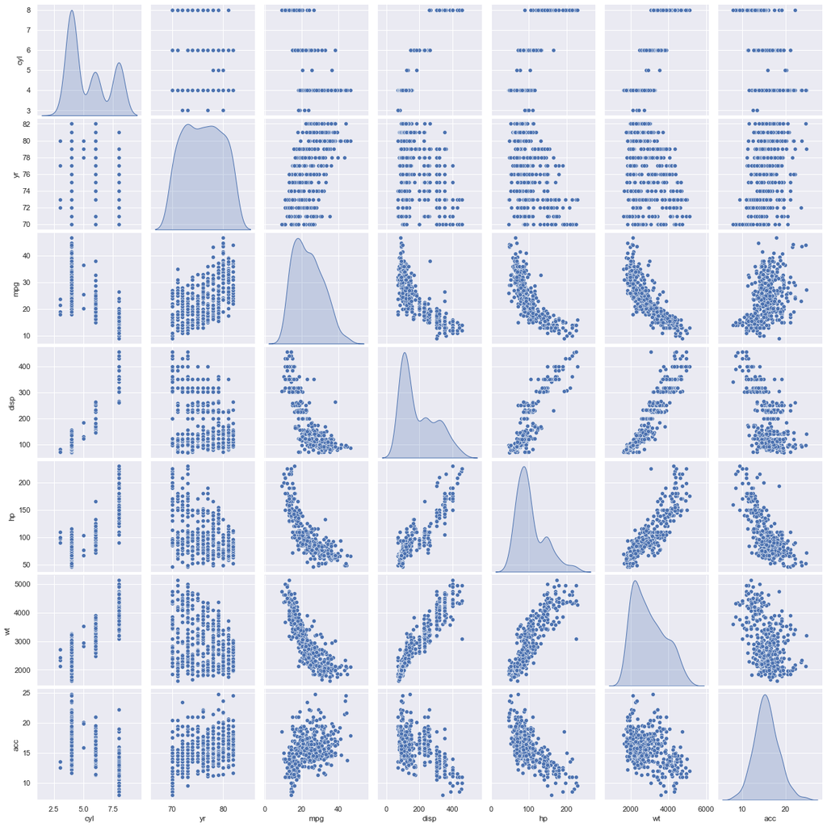

```python
df_attr = df.iloc[:, 0:7]
sns.pairplot(df_attr, diag_kind='kde');
```

There appears to be a linear relationship between the variables

```python
df2=df.drop(['origin_INDIA','origin_DUBAI','origin_TORONTO','mpg_level_high','mpg_level_low','mpg_level_medium'],axis=1)
```

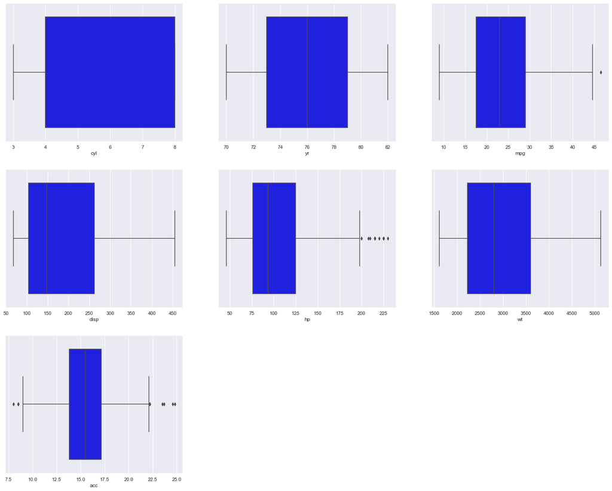

```python
plt.figure(figsize=(25, 20))
col = 1
for i in df2.columns:
    plt.subplot(3, 3, col)
    sns.boxplot(df2[i],color='blue')
    col += 1
```

```python
IQR1 = stats.iqr(df2['hp'], interpolation = 'midpoint')
IQR2 = stats.iqr(df2['acc'], interpolation = 'midpoint')
```

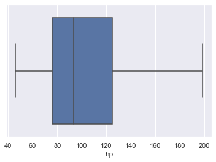

```python
Q3 = df2['hp'].quantile(0.75)
df2['hp'] = np.where(df2["hp"] >(Q3+1.5*IQR1), 198.5,df2['hp'])
sns.boxplot(df2['hp']);
```

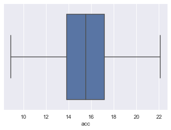

```python
Q1 = df2['acc'].quantile(0.25)
Q31 = df2['acc'].quantile(0.75)
df2['acc'] = np.where(df2["acc"] >(Q31+1.5*IQR2),22.10 ,df2['acc'])
df2['acc'] = np.where(df2["acc"] <(Q1-1.5*IQR2),(Q1-1.5*IQR2),df2['acc'])
sns.boxplot(df2['acc']);
```

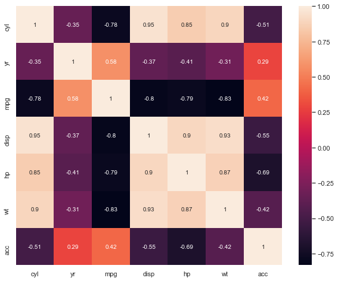

```python
plt.figure(figsize=(10,8))
corr=df2.corr()
sns.heatmap(corr,annot=True);
```

Except Year, most of the variable are correlated with each other

## 4. Machine learning:

```python
cc = df.iloc[:,0:7]
cc.head()
```

|  | cyl | yr | mpg | disp | hp | wt | acc |
| --- | --- | --- | --- | --- | --- | --- | --- |
| 0 | 8 | 70 | 18.0 | 307.0 | 130.0 | 3504 | 12.0 |
| 1 | 8 | 70 | 15.0 | 350.0 | 165.0 | 3693 | 11.5 |
| 2 | 8 | 70 | 18.0 | 318.0 | 150.0 | 3436 | 11.0 |
| 3 | 8 | 70 | 16.0 | 304.0 | 150.0 | 3433 | 12.0 |
| 4 | 8 | 70 | 17.0 | 302.0 | 140.0 | 3449 | 10.5 |

```python
cc_z = cc.apply(zscore)
cc_z.head()
```

|  | cyl | yr | mpg | disp | hp | wt | acc |
| --- | --- | --- | --- | --- | --- | --- | --- |
| 0 | 1.498191 | -1.627426 | -0.706439 | 1.090604 | 0.673118 | 0.630870 | -1.295498 |
| 1 | 1.498191 | -1.627426 | -1.090751 | 1.503514 | 1.589958 | 0.854333 | -1.477038 |
| 2 | 1.498191 | -1.627426 | -0.706439 | 1.196232 | 1.197027 | 0.550470 | -1.658577 |
| 3 | 1.498191 | -1.627426 | -0.962647 | 1.061796 | 1.197027 | 0.546923 | -1.295498 |
| 4 | 1.498191 | -1.627426 | -0.834543 | 1.042591 | 0.935072 | 0.565841 | -1.840117 |

```python
link_method = linkage(cc_z.iloc[:,0:7], method = 'average')
```

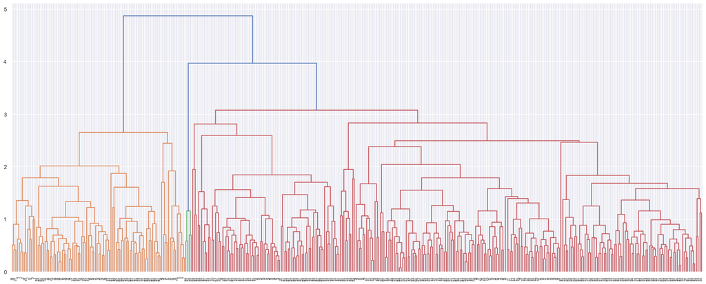

```python
plt.figure(figsize=(25, 10))
dendrogram(link_method)
plt.show()
```

Appers to be to much of a visual clutter, we'll go ahead and cut down the dendrogram to give us 2 clusters/groups

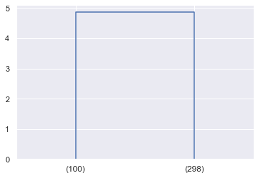

```python
dendrogram(
    link_method,
    truncate_mode='lastp',
    p=2,
)
plt.show()
```

```python
clusters = fcluster(link_method, 2, criterion='maxclust')
clusters
```

```
array([1, 1, 1, 1, 1, 1, 1, 1, 1, 1, 1, 1, 1, 1, 2, 2, 2, 2, 2, 2, 2, 2,
       2, 2, 2, 1, 1, 1, 1, 2, 2, 2, 2, 2, 2, 2, 2, 2, 1, 1, 1, 1, 1, 1,
       1, 2, 2, 2, 2, 2, 2, 2, 2, 2, 2, 2, 2, 2, 2, 2, 2, 2, 1, 1, 1, 1,
       1, 1, 1, 1, 1, 2, 1, 1, 1, 1, 2, 2, 2, 2, 2, 2, 2, 2, 2, 1, 1, 1,
       1, 1, 1, 1, 1, 1, 1, 1, 1, 2, 2, 2, 2, 2, 2, 1, 1, 1, 1, 2, 2, 2,
       2, 2, 2, 2, 2, 1, 1, 2, 2, 2, 2, 1, 2, 2, 1, 2, 2, 2, 2, 2, 2, 2,
       2, 2, 2, 2, 1, 1, 1, 1, 1, 2, 2, 2, 2, 2, 2, 2, 2, 2, 2, 2, 2, 2,
       2, 2, 1, 1, 1, 1, 2, 2, 2, 2, 2, 1, 1, 2, 2, 2, 2, 2, 2, 2, 2, 2,
       2, 2, 2, 2, 2, 2, 2, 2, 2, 2, 2, 1, 1, 1, 1, 2, 2, 2, 2, 2, 2, 2,
       2, 2, 2, 2, 2, 2, 2, 2, 2, 2, 1, 2, 2, 2, 1, 1, 1, 1, 2, 2, 2, 2,
       2, 1, 2, 1, 1, 2, 2, 2, 2, 1, 1, 1, 1, 2, 2, 2, 2, 2, 2, 2, 2, 2,
       2, 2, 2, 2, 2, 2, 2, 1, 1, 1, 2, 2, 2, 2, 2, 2, 2, 2, 2, 2, 1, 1,
       1, 1, 2, 2, 2, 2, 2, 2, 2, 2, 2, 2, 2, 2, 2, 2, 2, 2, 2, 2, 2, 1,
       1, 1, 1, 1, 1, 1, 1, 2, 2, 2, 2, 2, 2, 2, 2, 2, 2, 2, 2, 2, 2, 2,
       2, 2, 2, 2, 2, 2, 2, 2, 2, 2, 2, 2, 2, 2, 2, 2, 2, 2, 2, 2, 2, 2,
       2, 2, 2, 2, 2, 2, 2, 2, 2, 2, 2, 2, 2, 2, 2, 2, 2, 2, 2, 2, 2, 2,
       2, 2, 2, 2, 2, 2, 2, 2, 2, 2, 2, 2, 2, 2, 2, 2, 2, 2, 2, 2, 2, 2,
       2, 2, 2, 2, 2, 2, 2, 2, 2, 2, 2, 2, 2, 2, 2, 2, 2, 2, 2, 2, 2, 2,
       2, 2], dtype=int32)
```

```python
cc_z['clusters_H'] = clusters
cc_z.head()
```

|  | cyl | yr | mpg | disp | hp | wt | acc | clusters_H |
| --- | --- | --- | --- | --- | --- | --- | --- | --- |
| 0 | 1.498191 | -1.627426 | -0.706439 | 1.090604 | 0.673118 | 0.630870 | -1.295498 | 1 |
| 1 | 1.498191 | -1.627426 | -1.090751 | 1.503514 | 1.589958 | 0.854333 | -1.477038 | 1 |
| 2 | 1.498191 | -1.627426 | -0.706439 | 1.196232 | 1.197027 | 0.550470 | -1.658577 | 1 |
| 3 | 1.498191 | -1.627426 | -0.962647 | 1.061796 | 1.197027 | 0.546923 | -1.295498 | 1 |
| 4 | 1.498191 | -1.627426 | -0.834543 | 1.042591 | 0.935072 | 0.565841 | -1.840117 | 1 |

```python
cc_z.clusters_H.value_counts().sort_index()
```

```
1    100
2    298
Name: clusters_H, dtype: int64
```

```python
cc['clusters_H']=clusters
dfH['clusters_H']=clusters
cc.head()
```

|  | cyl | yr | mpg | disp | hp | wt | acc | clusters_H |
| --- | --- | --- | --- | --- | --- | --- | --- | --- |
| 0 | 8 | 70 | 18.0 | 307.0 | 130.0 | 3504 | 12.0 | 1 |
| 1 | 8 | 70 | 15.0 | 350.0 | 165.0 | 3693 | 11.5 | 1 |
| 2 | 8 | 70 | 18.0 | 318.0 | 150.0 | 3436 | 11.0 | 1 |
| 3 | 8 | 70 | 16.0 | 304.0 | 150.0 | 3433 | 12.0 | 1 |
| 4 | 8 | 70 | 17.0 | 302.0 | 140.0 | 3449 | 10.5 | 1 |

```python
Hclus=cc
Hclus.head()
```

|  | cyl | yr | mpg | disp | hp | wt | acc | clusters_H |
| --- | --- | --- | --- | --- | --- | --- | --- | --- |
| 0 | 8 | 70 | 18.0 | 307.0 | 130.0 | 3504 | 12.0 | 1 |
| 1 | 8 | 70 | 15.0 | 350.0 | 165.0 | 3693 | 11.5 | 1 |
| 2 | 8 | 70 | 18.0 | 318.0 | 150.0 | 3436 | 11.0 | 1 |
| 3 | 8 | 70 | 16.0 | 304.0 | 150.0 | 3433 | 12.0 | 1 |
| 4 | 8 | 70 | 17.0 | 302.0 | 140.0 | 3449 | 10.5 | 1 |

```python
aggdata=cc.iloc[:,0:8].groupby('clusters_H').mean()
aggdata['Freq']=cc.clusters_H.value_counts().sort_index()
aggdata
```

| clusters_H | cyl | yr | mpg | disp | hp | wt | acc | Freq |
| --- | --- | --- | --- | --- | --- | --- | --- | --- |
| 1 | 7.980000 | 73.740000 | 14.684000 | 345.470000 | 160.400000 | 4121.560000 | 12.702000 | 100 |
| 2 | 4.607383 | 76.771812 | 26.477852 | 142.404362 | 85.479866 | 2584.137584 | 16.529866 | 298 |

Clearly shows two disting group with a difference in average between the clusters and variables

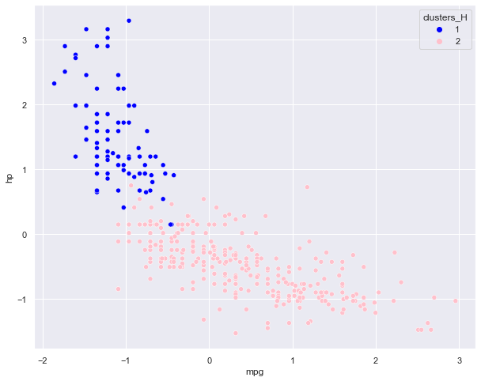

```python
plt.figure(figsize=(10, 8))
sns.scatterplot(x="mpg", y="hp", hue="clusters_H",
              data=cc_z,
                    palette=['blue','pink']);
```

## K-Means Clustering

```python
cc = df.iloc[:,0:7]
cc_z1 = cc.apply(zscore)
cc_z1.head()
```

|  | cyl | yr | mpg | disp | hp | wt | acc |
| --- | --- | --- | --- | --- | --- | --- | --- |
| 0 | 1.498191 | -1.627426 | -0.706439 | 1.090604 | 0.673118 | 0.630870 | -1.295498 |
| 1 | 1.498191 | -1.627426 | -1.090751 | 1.503514 | 1.589958 | 0.854333 | -1.477038 |
| 2 | 1.498191 | -1.627426 | -0.706439 | 1.196232 | 1.197027 | 0.550470 | -1.658577 |
| 3 | 1.498191 | -1.627426 | -0.962647 | 1.061796 | 1.197027 | 0.546923 | -1.295498 |
| 4 | 1.498191 | -1.627426 | -0.834543 | 1.042591 | 0.935072 | 0.565841 | -1.840117 |

```python
wss =[]
for i in range(1,5):
    KM = KMeans(n_clusters=i)
    KM.fit(cc_z1)
    wss.append(KM.inertia_)
wss
```

```
[2785.9999999999995, 1294.8418950727323, 946.019790855379, 738.3743876111228]
```

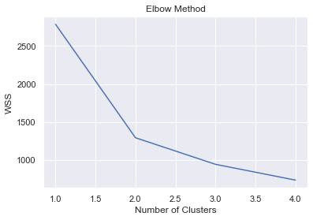

```python
plt.plot(range(1,5), wss);
plt.title('Elbow Method');
plt.xlabel("Number of Clusters")
plt.ylabel("WSS");
```

```python
k_means = KMeans(n_clusters = 2)
k_means.fit(cc_z1)
labels = k_means.labels_
```

```python
silhouette_score(cc_z1,labels)
```

```
0.48235946103916116
```

```python
kmeans_kwargs = {
   "init": "random",
   "n_init": 10,
   "max_iter": 300,
   "random_state": 42,
}
silhouette_coefficients = []
for k in range(2, 7):
    kmeans = KMeans(n_clusters=k, **kmeans_kwargs)
    kmeans.fit(cc_z1)
    score = silhouette_score(cc_z1,kmeans.labels_)
    silhouette_coefficients.append(score)
```

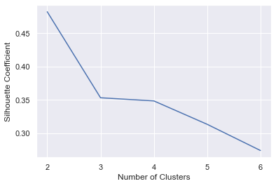

```python
plt.plot(range(2, 7), silhouette_coefficients)
plt.xticks(range(2, 7))
plt.xlabel("Number of Clusters")
plt.ylabel("Silhouette Coefficient")
plt.show()
```

```python
cc["cluster_K"] = labels
dfK['cluster_K']=labels
Kclus=cc
Kclus.head()
```

|  | cyl | yr | mpg | disp | hp | wt | acc | cluster_K |
| --- | --- | --- | --- | --- | --- | --- | --- | --- |
| 0 | 8 | 70 | 18.0 | 307.0 | 130.0 | 3504 | 12.0 | 1 |
| 1 | 8 | 70 | 15.0 | 350.0 | 165.0 | 3693 | 11.5 | 1 |
| 2 | 8 | 70 | 18.0 | 318.0 | 150.0 | 3436 | 11.0 | 1 |
| 3 | 8 | 70 | 16.0 | 304.0 | 150.0 | 3433 | 12.0 | 1 |
| 4 | 8 | 70 | 17.0 | 302.0 | 140.0 | 3449 | 10.5 | 1 |

```python
cc.cluster_K.value_counts().sort_index()
```

```
0    293
1    105
Name: cluster_K, dtype: int64
```

```python
cc_z1["cluster_K"] = labels
cc_z1.head()
```

|  | cyl | yr | mpg | disp | hp | wt | acc | cluster_K |
| --- | --- | --- | --- | --- | --- | --- | --- | --- |
| 0 | 1.498191 | -1.627426 | -0.706439 | 1.090604 | 0.673118 | 0.630870 | -1.295498 | 1 |
| 1 | 1.498191 | -1.627426 | -1.090751 | 1.503514 | 1.589958 | 0.854333 | -1.477038 | 1 |
| 2 | 1.498191 | -1.627426 | -0.706439 | 1.196232 | 1.197027 | 0.550470 | -1.658577 | 1 |
| 3 | 1.498191 | -1.627426 | -0.962647 | 1.061796 | 1.197027 | 0.546923 | -1.295498 | 1 |
| 4 | 1.498191 | -1.627426 | -0.834543 | 1.042591 | 0.935072 | 0.565841 | -1.840117 | 1 |

```python
aggdata=cc.iloc[:,0:8].groupby('cluster_K').mean()
aggdata['Freq']=cc.cluster_K.value_counts().sort_index()
aggdata
```

| cluster_K | cyl | yr | mpg | disp | hp | wt | acc | Freq |
| --- | --- | --- | --- | --- | --- | --- | --- | --- |
| 0 | 4.569966 | 76.822526 | 26.619113 | 140.250853 | 85.061433 | 2567.860068 | 16.535836 | 293 |
| 1 | 7.923810 | 73.742857 | 14.851429 | 341.809524 | 158.000000 | 4093.771429 | 12.867619 | 105 |

Clearly shows two disting group with a difference in average between the clusters and variables

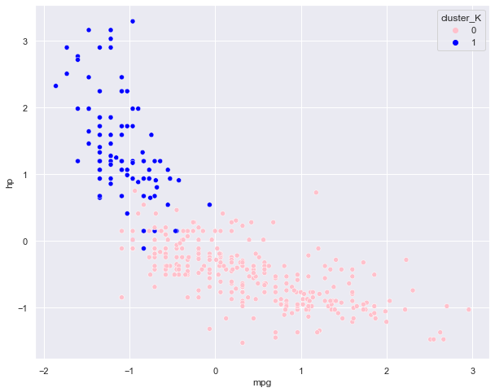

```python
plt.figure(figsize=(10, 8))
sns.scatterplot(x="mpg", y="hp", hue="cluster_K",
              data=cc_z1,
                    palette=['pink','blue']);
```

```python
dfH.clusters_H.value_counts().sort_index()
```

```
1    100
2    298
Name: clusters_H, dtype: int64
```

```python
dfK.cluster_K.value_counts().sort_index()
```

```
0    293
1    105
Name: cluster_K, dtype: int64
```

```python
dfH.shape
```

```
(398, 14)
```

```python
dfK.shape
```

```
(398, 14)
```

```python
df.head()
```

|  | cyl | yr | mpg | disp | hp | wt | acc | origin_DUBAI | origin_INDIA | origin_TORONTO | mpg_level_high | mpg_level_low | mpg_level_medium |
| --- | --- | --- | --- | --- | --- | --- | --- | --- | --- | --- | --- | --- | --- |
| 0 | 8 | 70 | 18.0 | 307.0 | 130.0 | 3504 | 12.0 | 0 | 1 | 0 | 0 | 0 | 1 |
| 1 | 8 | 70 | 15.0 | 350.0 | 165.0 | 3693 | 11.5 | 0 | 1 | 0 | 0 | 1 | 0 |
| 2 | 8 | 70 | 18.0 | 318.0 | 150.0 | 3436 | 11.0 | 0 | 1 | 0 | 0 | 0 | 1 |
| 3 | 8 | 70 | 16.0 | 304.0 | 150.0 | 3433 | 12.0 | 0 | 1 | 0 | 0 | 1 | 0 |
| 4 | 8 | 70 | 17.0 | 302.0 | 140.0 | 3449 | 10.5 | 0 | 1 | 0 | 0 | 0 | 1 |

## 5. Answer below questions based on outcomes of using ML based methods.

## Linear regression on the original dataset

```python
X = df.drop(['mpg','origin_DUBAI','mpg_level_low'], axis=1)
y = df[['mpg']]
```

```python
X_train, X_test, y_train, y_test = train_test_split(X, y, test_size=0.30, random_state=15)
```

```python
regression_model = LinearRegression()
regression_model.fit(X_train, y_train)
```

```
LinearRegression()
```

```python
for idx, col_name in enumerate(X_train.columns):
    print("The coefficient for {} is {}".format(col_name, regression_model.coef_[0][idx]))
```

```
The coefficient for cyl is -0.5134441386218929
The coefficient for yr is 0.44346504291168326
The coefficient for disp is 0.010688858394647005
The coefficient for hp is 0.010315514536313984
The coefficient for wt is -0.004538788568737149
The coefficient for acc is 0.19183425608862584
The coefficient for origin_INDIA is -1.7306209513689026
The coefficient for origin_TORONTO is -0.8976724344009384
The coefficient for mpg_level_high is 8.55237466381703
The coefficient for mpg_level_medium is 1.5941218694850463
```

```python
intercept = regression_model.intercept_[0]
print("The intercept for our model is {}".format(intercept))
```

```
The intercept for our model is -1.6635717568650534
```

```python
regression_model.score(X_train, y_train)
```

```
0.8967703023839786
```

```python
O=regression_model.score(X_test, y_test)
O
```

```
0.9037421476349176
```

## Linear regression on data with K means cluster

```python
dfK['cluster_K'] = dfK['cluster_K'].astype('category')
dfK['cluster_K'] = dfK['cluster_K'].replace({1: 'heavy', 0: 'light'})
dfK = pd.get_dummies(dfK, columns=['cluster_K'])
```

```python
dfK.head()
```

|  | cyl | yr | mpg | disp | hp | wt | acc | origin_DUBAI | origin_INDIA | origin_TORONTO | mpg_level_high | mpg_level_low | mpg_level_medium | cluster_K_heavy | cluster_K_light |
| --- | --- | --- | --- | --- | --- | --- | --- | --- | --- | --- | --- | --- | --- | --- | --- |
| 0 | 8 | 70 | 18.0 | 307.0 | 130.0 | 3504 | 12.0 | 0 | 1 | 0 | 0 | 0 | 1 | 1 | 0 |
| 1 | 8 | 70 | 15.0 | 350.0 | 165.0 | 3693 | 11.5 | 0 | 1 | 0 | 0 | 1 | 0 | 1 | 0 |
| 2 | 8 | 70 | 18.0 | 318.0 | 150.0 | 3436 | 11.0 | 0 | 1 | 0 | 0 | 0 | 1 | 1 | 0 |
| 3 | 8 | 70 | 16.0 | 304.0 | 150.0 | 3433 | 12.0 | 0 | 1 | 0 | 0 | 1 | 0 | 1 | 0 |
| 4 | 8 | 70 | 17.0 | 302.0 | 140.0 | 3449 | 10.5 | 0 | 1 | 0 | 0 | 0 | 1 | 1 | 0 |

```python
X = dfK.drop(['mpg','origin_DUBAI','mpg_level_low','cluster_K_light'], axis=1)
y = dfK[['mpg']]
```

```python
X_train, X_test, y_train, y_test = train_test_split(X, y, test_size=0.30, random_state=12)
```

```python
regression_model = LinearRegression()
regression_model.fit(X_train, y_train)
```

```
LinearRegression()
```

```python
for idx, col_name in enumerate(X_train.columns):
    print("The coefficient for {} is {}".format(col_name, regression_model.coef_[0][idx]))
```

```
The coefficient for cyl is -1.1945995644777512
The coefficient for yr is 0.43186510415059765
The coefficient for disp is 0.01747749627910991
The coefficient for hp is -0.010138045835905822
The coefficient for wt is -0.004068430169386408
The coefficient for acc is 0.1856482874625017
The coefficient for origin_INDIA is -1.6918315494304048
The coefficient for origin_TORONTO is -0.740777919230302
The coefficient for mpg_level_high is 9.28312093915688
The coefficient for mpg_level_medium is 2.250001714231251
The coefficient for cluster_K_heavy is 2.5115140143384744
```

```python
intercept = regression_model.intercept_[0]
print("The intercept for our model is {}".format(intercept))
```

```
The intercept for our model is 1.2041468067172296
```

```python
regression_model.score(X_train, y_train)
```

```
0.8942370456543636
```

```python
K=regression_model.score(X_test, y_test)
K
```

```
0.9117893808052381
```

## Linear regression on data with H-clusters

```python
#renaming the cluster labels to light and heavy vehicles and creating summy variable of it
dfH['clusters_H'] = dfH['clusters_H'].astype('category')
dfH['clusters_H'] = dfH['clusters_H'].replace({1: 'heavy', 2: 'light'})
dfH = pd.get_dummies(dfH, columns=['clusters_H'])
```

```python
X = dfH.drop(['mpg','origin_DUBAI','mpg_level_low','clusters_H_light'], axis=1)
y = dfH[['mpg']]
```

```python
X_train, X_test, y_train, y_test = train_test_split(X, y, test_size=0.30, random_state=10)
```

```python
regression_model = LinearRegression()
regression_model.fit(X_train, y_train)
```

```
LinearRegression()
```

```python
for idx, col_name in enumerate(X_train.columns):
    print("The coefficient for {} is {}".format(col_name, regression_model.coef_[0][idx]))
```

```
The coefficient for cyl is -1.0104832432575337
The coefficient for yr is 0.4475417357550159
The coefficient for disp is 0.01511520052461449
The coefficient for hp is -0.013301584387234262
The coefficient for wt is -0.0042641797806725655
The coefficient for acc is 0.11805139164484654
The coefficient for origin_INDIA is -2.1174569315391114
The coefficient for origin_TORONTO is -1.3974915348558097
The coefficient for mpg_level_high is 8.565948239298276
The coefficient for mpg_level_medium is 1.6577250698582757
The coefficient for clusters_H_heavy is 2.03897446880741
```

```python
intercept = regression_model.intercept_[0]
print("The intercept for our model is {}".format(intercept))
```

```
The intercept for our model is 2.5727293182325965
```

```python
regression_model.score(X_train, y_train)
```

```
0.8988409890950728
```

```python
H=regression_model.score(X_test, y_test)
H
```

```
0.901023837384672
```

```python
modellists = []
modellists.append(['Linear Regression on Original Data set', O*100])
modellists.append(['Linear Regression with K means clusters', K*100])
modellists.append(['Linear Regression with Heirarchical clusters', H*100])
mdl_df = pd.DataFrame(modellists, columns = ['Model','r^2 on Test'])
mdl_df
```

|  | Model | r^2 on Test |
| --- | --- | --- |
| 0 | Linear Regression on Original Data set | 90.374215 |
| 1 | Linear Regression with K means clusters | 91.178938 |
| 2 | Linear Regression with Heirarchical clusters | 90.102384 |

## 6. Improvisation:

K-means appears to explain the highest variation in the datset, but with a difference of only 1% when compared with other models, to get more clarity a larger dataset may be used, since this is a dataset of used cars it doesn't give us how many previous owners has the cars seen which might be helful variable,the gender of the previous owners, the reason/purpose that the cars were being used is also an important factor which the dataset doen't capture. With the above mentioned features it may be possible to get a higher accuracy or explainability of the models and its variables.